# SI 370 Homework #3

## Taylor Swift songs

Last updated 2023-10-04

The dataset for this assignment is from https://www.kaggle.com/datasets/jarredpriester/taylor-swift-spotify-dataset/data.

**NOTE**: Use the dataset from Canvas rather than the dataset from Kaggle, which is updated frequently and may change while you are completing this assignment.

This dataset consist of data from Spotify's API on all albums listed on Spotify for Taylor Swift. I set up the dataset to update monthly so that if any albums get added it will get added to the dataset too. At first it may look like there are song duplicates but I checked and all song IDs are unique.

The columns in this dataset are:

name - the name of the song

album - the name of the album

release_date - the day month and year the album was released

track number - the order the song appears on the album

id - the Spotify id for the song

uri - the Spotify uri for the song

acousticness - A confidence measure from 0.0 to 1.0 of whether the track is acoustic. 1.0 represents high confidence the track is acoustic.

danceability - Danceability describes how suitable a track is for dancing based on a combination of musical elements including tempo, rhythm stability, beat strength, and overall regularity. A value of 0.0 is least danceable and 1.0 is most danceable.

energy - Energy is a measure from 0.0 to 1.0 and represents a perceptual measure of intensity and activity. Typically, energetic tracks feel fast, loud, and noisy. For example, death metal has high energy, while a Bach prelude scores low on the scale. Perceptual features contributing to this attribute include dynamic range, perceived loudness, timbre, onset rate, and general entropy.

instrumentalness - Predicts whether a track contains no vocals. "Ooh" and "aah" sounds are treated as instrumental in this context. Rap or spoken word tracks are clearly "vocal". The closer the instrumentalness value is to 1.0, the greater likelihood the track contains no vocal content. Values above 0.5 are intended to represent instrumental tracks, but confidence is higher as the value approaches 1.0.

liveness - Detects the presence of an audience in the recording. Higher liveness values represent an increased probability that the track was performed live. A value above 0.8 provides strong likelihood that the track is live.

loudness - The overall loudness of a track in decibels (dB). Loudness values are averaged across the entire track and are useful for comparing relative loudness of tracks. Loudness is the quality of a sound that is the primary psychological correlate of physical strength (amplitude). Values typically range between -60 and 0 db.

speechiness - detects the presence of spoken words in a track. The more exclusively speech-like the recording (e.g. talk show, audio book, poetry), the closer to 1.0 the attribute value. Values above 0.66 describe tracks that are probably made entirely of spoken words. Values between 0.33 and 0.66 describe tracks that may contain both music and speech, either in sections or layered, including such cases as rap music. Values below 0.33 most likely represent music and other non-speech-like tracks.

tempo - The overall estimated tempo of a track in beats per minute (BPM). In musical terminology, tempo is the speed or pace of a given piece and derives directly from the average beat duration.

valence - A measure from 0.0 to 1.0 describing the musical positiveness conveyed by a track. Tracks with high valence sound more positive (e.g. happy, cheerful, euphoric), while tracks with low valence sound more negative (e.g. sad, depressed, angry).

popularity - the popularity of the song from 0 to 100

duration_ms - The duration of the track in milliseconds.

We are going to refer to the tracks' properties of danceability, energy, instrumentalness, liveness, loudness, speechiness, tempo, and valence as "features" of the tracks.

Each of the questions is worth the same number of points, except for the final bonus question, which is worth up to an additional 1 point (out of 20). Points will be allocated according to the following rubric:

- 90-100%: Question is correctly and completely answered. Answer consists of well-written code that conforms to [PEP 8](https://www.python.org/dev/peps/pep-0008/) guidelines and is accompanied by a written interpretation in a Markdown block. Written interpretation does not contain spelling, grammar or stylistic errors (see [Strunk & White](https://drive.google.com/file/d/1L0P7xJwjUGBvyb49mL3dw1Bt7hzRTiTl/view?usp=sharing) for a detailed specifications). Minor problems, such as formatting, incorrect submissions, missing names, etc. will result in less than 100%.
- 75-85% : Answer is mostly complete and correct; two or fewer noticeable omissions or errors. Minor stylistic flaws, either in code or in written interpretation.
- 50-70%: Answer has significant omissions or errors; Noticeable departure from PEP-8 guildelines and/or moderate spelling, grammar, or style issues in written interpretations.
- 25-45%: Question is perfunctorily attempted. Substantial parts are missing or incorrect.
- 0 points: Question not attempted.

Be sure to include interpretations of your results for each question.

```python
import pandas as pd
import seaborn as sns
import numpy as np
import matplotlib.pyplot as plt

data = pd.read_csv('/Users/jason/Desktop/SI 370 Master/si370fa23-student-main 2/data/taylor_swift_spotify.csv')
data.head()
```

|  | Unnamed: 0 | name | album | release_date | track_number | id | uri | acousticness | danceability | energy | instrumentalness | liveness | loudness | speechiness | tempo | valence | popularity | duration_ms |
| --- | --- | --- | --- | --- | --- | --- | --- | --- | --- | --- | --- | --- | --- | --- | --- | --- | --- | --- |
| 0 | 0 | Lavender Haze | Midnights (3am Edition) | 2022-10-22 | 1 | 4g2c7NoTWAOSYDy44l9nub | spotify:track:4g2c7NoTWAOSYDy44l9nub | 0.2040 | 0.735 | 0.444 | 0.001200 | 0.1700 | -10.519 | 0.0684 | 97.038 | 0.0984 | 77 | 202395 |
| 1 | 1 | Maroon | Midnights (3am Edition) | 2022-10-22 | 2 | 199E1RRrVmVTQqBXih5qRC | spotify:track:199E1RRrVmVTQqBXih5qRC | 0.0593 | 0.658 | 0.378 | 0.000000 | 0.0976 | -8.300 | 0.0379 | 108.034 | 0.0382 | 76 | 218270 |
| 2 | 2 | Anti-Hero | Midnights (3am Edition) | 2022-10-22 | 3 | 02Zkkf2zMkwRGQjZ7T4p8f | spotify:track:02Zkkf2zMkwRGQjZ7T4p8f | 0.1330 | 0.638 | 0.634 | 0.000001 | 0.1520 | -6.582 | 0.0457 | 96.953 | 0.5190 | 77 | 200690 |
| 3 | 3 | Snow On The Beach (feat. Lana Del Rey) | Midnights (3am Edition) | 2022-10-22 | 4 | 6ADDIJxxqzM9LMpm78yzQG | spotify:track:6ADDIJxxqzM9LMpm78yzQG | 0.7350 | 0.659 | 0.323 | 0.003210 | 0.1160 | -13.425 | 0.0436 | 110.007 | 0.1540 | 74 | 256124 |
| 4 | 4 | You're On Your Own, Kid | Midnights (3am Edition) | 2022-10-22 | 5 | 7gVWKBcfIW93YxNBi3ApIE | spotify:track:7gVWKBcfIW93YxNBi3ApIE | 0.4160 | 0.694 | 0.380 | 0.000008 | 0.1260 | -10.307 | 0.0614 | 120.044 | 0.3760 | 76 | 194206 |

Q1: Show the distribution of the popularity of the songs. Then exclude the songs that are from karaoke albums (i.e., the album name contains "karaoke"). Show the distribution of the popularity of the songs. What is the difference between the two distributions?

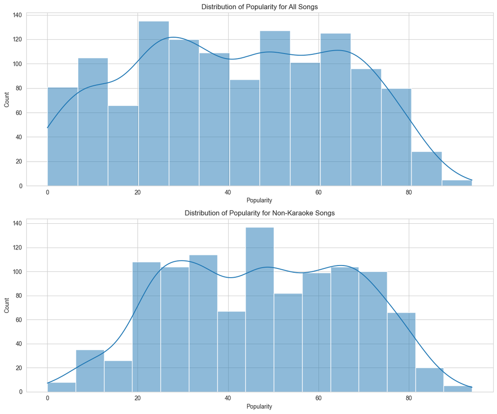

```python
sns.set_style("whitegrid")

fig, axes = plt.subplots(nrows=2, ncols=1, figsize=(12, 10))

sns.histplot(data=data, x='popularity', kde=True, ax=axes[0])
axes[0].set_title('Distribution of Popularity for All Songs')
axes[0].set_xlabel('Popularity')
axes[0].set_ylabel('Count')

non_karaoke_data = data[~data['album'].str.contains("karaoke", case=False, na=False)]

sns.histplot(data=non_karaoke_data, x='popularity', kde=True, ax=axes[1])
axes[1].set_title('Distribution of Popularity for Non-Karaoke Songs')
axes[1].set_xlabel('Popularity')
axes[1].set_ylabel('Count')

plt.tight_layout()
plt.show()
```

### IMPORTANT NOTE: the remainder of the questions are based on the songs that are NOT from karaoke albums.

Q2: Report the average track duration for each album. You answer should be in mm:ss (minutes:seconds) format rather than the milliseconds that are reported in the original dataset.

```python
album_avg_duration = non_karaoke_data.groupby('album')['duration_ms'].mean()
album_avg_duration_mm_ss = album_avg_duration.apply(lambda x: "{:02d}:{:02d}".format(int(x) // 60000, (int(x) % 60000) // 1000))
album_avg_duration_mm_ss.sort_values(ascending=False)
```

```
album
Speak Now World Tour Live                                                              04:57
Speak Now (US Version)                                                                 04:47
Speak Now                                                                              04:47
Speak Now (Japanese Version)                                                           04:46
Speak Now (Deluxe Package)                                                             04:35
Speak Now (Deluxe Edition)                                                             04:35
Red (Taylor's Version)                                                                 04:21
Fearless (Platinum Edition)                                                            04:10
Fearless Platinum Edition                                                              04:10
Red (Deluxe Edition)                                                                   04:06
Fearless (Taylor's Version)                                                            04:05
Red                                                                                    04:04
evermore (deluxe version)                                                              04:03
evermore                                                                               04:03
reputation Stadium Tour Surprise Song Playlist                                         04:02
Fearless                                                                               04:00
Fearless (International Version)                                                       04:00
folklore                                                                               03:58
folklore: the long pond studio sessions (from the Disney+ special) [deluxe edition]    03:57
folklore (deluxe version)                                                              03:56
1989                                                                                   03:45
reputation                                                                             03:43
1989 (Deluxe Edition)                                                                  03:41
1989 (Deluxe)                                                                          03:37
Taylor Swift                                                                           03:33
Live From Clear Channel Stripped 2008                                                  03:29
Midnights (3am Edition)                                                                03:28
Lover                                                                                  03:26
Midnights                                                                              03:23
Speak Now (Big Machine Radio Release Special)                                          02:59
reputation (Big Machine Radio Release Special)                                         02:44
Red (Big Machine Radio Release Special)                                                02:38
1989 (Big Machine Radio Release Special)                                               02:37
Fearless (Big Machine Radio Release Special)                                           02:33
Taylor Swift (Big Machine Radio Release Special)                                       02:26
Name: duration_ms, dtype: object
```

From the list above, we can see the in order the longest average track duration is from Speak Now World Tour Live at 4:57 and the shortest is Taylor Swift (Big Machine Radio Release Special) which is 2:26.

Q3: Show a heatmap of the correlations between the features. Use a diverging colormap with white in the middle (i.e. white at a correlation of 0.0).

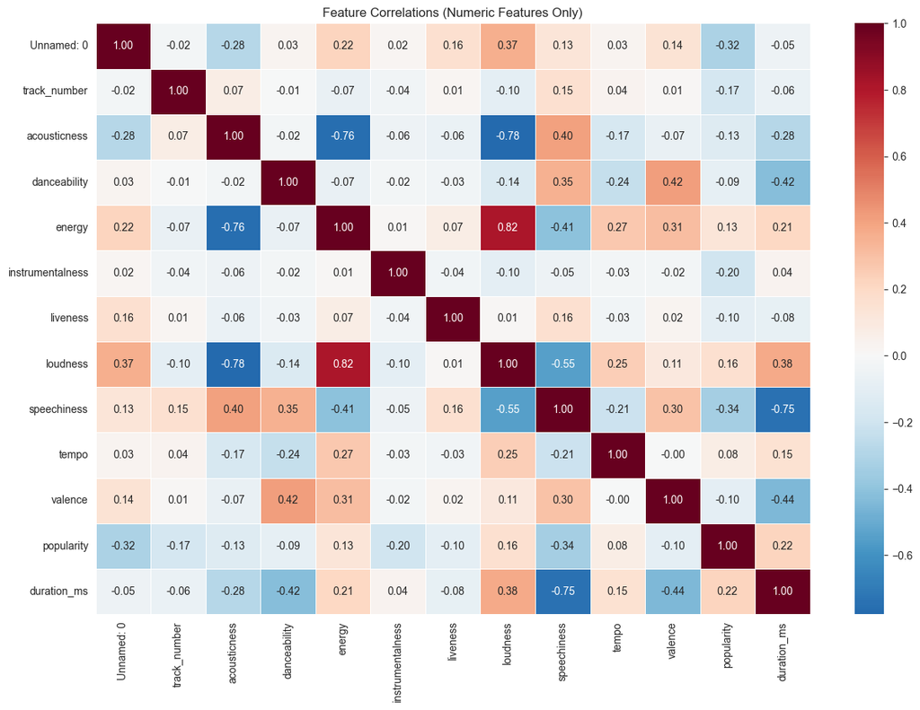

```python
numeric_data = non_karaoke_data.select_dtypes(include=['float64', 'int64'])

correlation_matrix_numeric = numeric_data.corr()

plt.figure(figsize=(15, 10))
sns.heatmap(correlation_matrix_numeric, cmap="RdBu_r", center=0, annot=True, fmt=".2f", linewidths=0.5)
plt.title("Feature Correlations (Numeric Features Only)")
plt.show()
```

The strongest correlation observed was between energy and loudness, suggesting that louder songs are perceived as more energetic. There's a notable negative correlation between acousticness and energy, indicating that more acoustic songs tend to be less energetic.

Q4: List the top 5 correlations between the features of the songs.

```python
upper_tri = correlation_matrix_numeric.where(np.triu(np.ones(correlation_matrix_numeric.shape), k=1).astype(bool))
sorted_correlations_corrected = upper_tri.stack().abs().sort_values(ascending=False).head(5)
sorted_correlations_corrected
```

```
energy        loudness       0.817729
acousticness  loudness       0.777471
              energy         0.756873
speechiness   duration_ms    0.747227
loudness      speechiness    0.549766
dtype: float64
```

This strong positive correlation suggests that songs perceived as more energetic tend to be louder. This relationship is intuitive as energetic tracks, like those in genres such as rock or electronic, often have higher volume levels. Artists and producers can consider this correlation when creating energetic tracks or remixes when trying to tailor to certain listeners preferences.

Q5: Does the position of the track on the album (i.e. track number) have an effect on the popularity of the song? Use both visual and statistical evidence to support your answer.

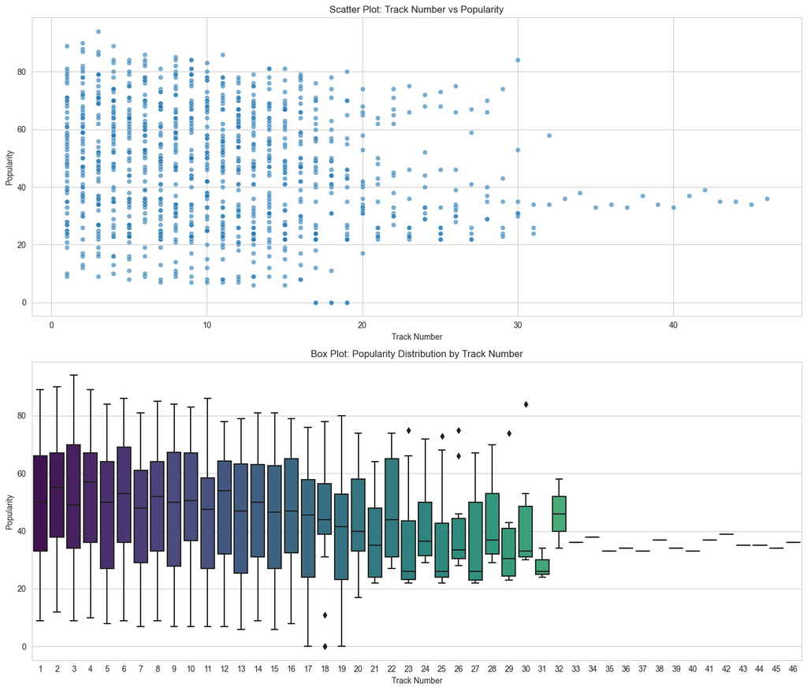

```python
fig, axes = plt.subplots(nrows=2, ncols=1, figsize=(14, 12))

sns.scatterplot(data=non_karaoke_data, x='track_number', y='popularity', alpha=0.6, ax=axes[0])
axes[0].set_title('Scatter Plot: Track Number vs Popularity')
axes[0].set_xlabel('Track Number')
axes[0].set_ylabel('Popularity')

sns.boxplot(data=non_karaoke_data, x='track_number', y='popularity', ax=axes[1], palette='viridis')
axes[1].set_title('Box Plot: Popularity Distribution by Track Number')
axes[1].set_xlabel('Track Number')
axes[1].set_ylabel('Popularity')

plt.tight_layout()
plt.show()
```

```python
from scipy.stats import pearsonr, linregress
correlation_coefficient, p_value_corr = pearsonr(non_karaoke_data['track_number'], non_karaoke_data['popularity'])
slope, intercept, r_value, p_value_reg, std_err = linregress(non_karaoke_data['track_number'], non_karaoke_data['popularity'])
correlation_coefficient, p_value_corr, r_value**2, p_value_reg
```

```
(-0.1740355403369844,
 9.280428374314722e-09,
 0.030288369300386114,
 9.28042837431496e-09)
```

There's a statistically significant but weak inverse relationship between a song's position in an album (track number) and its popularity. Songs positioned earlier in an album tend to be slightly more popular than those positioned later. However, the position of a song on an album explains only a small portion of its popularity, suggesting that other factors play more significant roles in determining a song's success.

Q6: Are popular songs more danceable? Divide the songs into popular (i.e. those with a popularity rating of 60 or higher) and less popular (i.e. those with a popularity rating of less than 60). Conduct an ANOVA test for the two groups of data based on danceability feature. Are they statistically significant?

```python
import scipy.stats as stats

popular_songs = non_karaoke_data[non_karaoke_data['popularity'] >= 60]['danceability']
less_popular_songs = non_karaoke_data[non_karaoke_data['popularity'] < 60]['danceability']

f_statistic, p_value_anova = stats.f_oneway(popular_songs, less_popular_songs)

f_statistic, p_value_anova
```

```
(4.435696553436213, 0.03542666084019701)
```

Q7: Create a regression model with "popularity" as the dependent variable and "liveness" as the predictor variable. Report the following:

1. Coefficient of determination (i.e. $r^2$)
2. Whether the regression is statistically significant
3. An estimate for the value of "popularity" when the value of "liveness" is 0.22.

```python
slope, intercept, r_value, p_value, std_err = linregress(non_karaoke_data['liveness'], non_karaoke_data['popularity'])

r_squared = r_value**2

popularity_estimate = slope * 0.22 + intercept

r_squared, p_value, popularity_estimate
```

```
(0.00934790425683388, 0.0015047537078467558, 46.30295598962271)
```

There's a statistically significant relationship between "liveness" and "popularity". While there's evidence of a linear relationship, the "liveness" of a song by itself doesn't strongly predict its popularity. Songs with a "liveness" value of 0.22, which might suggest a moderate level of audience noise or interaction, have an estimated popularity score of around 46.30. However, given the weak relationship, other factors likely play a more substantial role in determining a song's popularity.

Q8: Due to intellectual property conflicts, Taylor Swift re-recorded some of her earlier albums, including `Fearless`, `Red` and `Speak Now`. We assume that re-recording her early albums will allow Taylor Swift to reclaim her artistry control, revisit the songs and make any changes she wants. Therefore, we want to see whether the new songs are more loved by the audiences by looking at the popularity score.

- The re-recorded ones have `(Taylor’s version)` at the end of the album name.
- We will ignore the Speak Now World Tour Live version. Therefore there are 5 albums as original and 3 as re-recorded

a) Create a visualization that shows the distribution of popularity scores of original vs. re-recorded songs. There are multiple visualizations that would be appropriate here. You can choose any of them. At a minimum, you should create one visualization. Creating additional ones can earn you additional points.

b) Is there a statistically significant difference between the popularity scores of the original and re-recorded songs? If so, which one is more popular? How much more popular is it, on average?

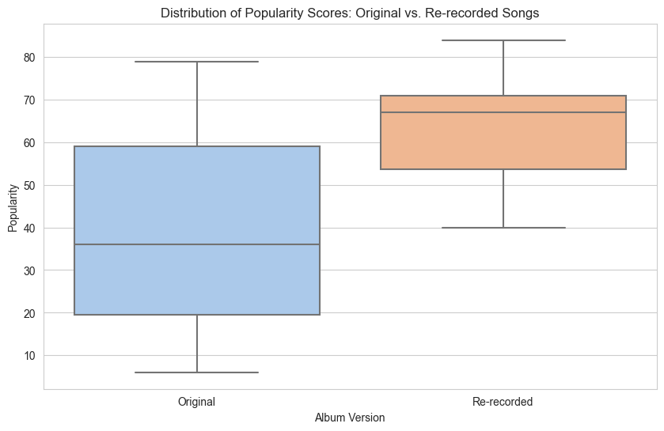

```python
original_albums = ['Fearless', 'Red', 'Speak Now']
re_recorded_albums = [album + ' (Taylor\'s Version)' for album in original_albums]

original_data = non_karaoke_data[non_karaoke_data['album'].isin(original_albums) & (non_karaoke_data['album'] != 'Speak Now World Tour Live')]
re_recorded_data = non_karaoke_data[non_karaoke_data['album'].isin(re_recorded_albums)]

original_data['Version'] = 'Original'
re_recorded_data['Version'] = 'Re-recorded'

combined_data = pd.concat([original_data, re_recorded_data])

plt.figure(figsize=(10, 6))
sns.boxplot(x='Version', y='popularity', data=combined_data, palette='pastel')
plt.title('Distribution of Popularity Scores: Original vs. Re-recorded Songs')
plt.ylabel('Popularity')
plt.xlabel('Album Version')
plt.show()
```

```python
t_statistic, p_value_ttest = stats.ttest_ind(original_data['popularity'], re_recorded_data['popularity'])

mean_original = original_data['popularity'].mean()
mean_rerecorded = re_recorded_data['popularity'].mean()

t_statistic, p_value_ttest, mean_original, mean_rerecorded, mean_rerecorded - mean_original
```

```
(-9.601672141918518,
 2.73276775747375e-18,
 38.40650406504065,
 63.16279069767442,
 24.756286632633767)
```

The box-and-whisker plot visually showed that re-recorded versions of Taylor Swift's earlier albums are more popular than their original counterparts. The statistical analysis further confirmed this, indicating a significant increase in popularity for the re-recorded songs. This suggests a favorable reception by the audience for Taylor Swift's re-recorded tracks, possibly due to the quality of the re-recordings, external factors like media coverage, fan support, or the sentiment surrounding the re-recording initiative.

BONUS, worth up to 1 point: How would you determine whether [Taylor Swift has had an effect on the popularity of football](https://duckduckgo.com/?q=taylor+swift+football&atb=v314-1&ia=web)? What data would you need? What analysis would you perform? What would you expect the results to be?

In order to determine whether Taylor Swift has had an effect on the popularity of football, we would need data on viewership data before and after she began attending games. I think it would be really interesting to see the breakdown between genders in viewership because I would guess that more females have been watching Cheifs games as a result of Taylor Swift being televised during the game. In order to perform this analysis I would use a statistical tests (e.g., t-tests or regression analysis) to determine if any observed increase in NFL popularity after Taylor Swift's attendance is statistically significant or if it could have occurred by chance. I would expect that she has caused an increase in popularity among females viewers as well as merchandise sales for the Cheifs NFL team.

### Submit your completed assignment in both IPYNB and HTML formats.